# The Posthumous Classification Exercise at Scale

Bot exclusions, item-level results, and comparison with the open-ended pilot

Author

Jamie C. Lee

Published

September 4, 2026

## Summary

This document repeats the **classification exercise** analysis from `extended_self_qual.qmd` on a large sample (*N* = 120 collected, *N* = 115 after exclusions), applies the **bot-exclusion rules** from `ep_literacy_analysis.qmd`, and then asks directly whether the pilot’s item-level conclusions held up.

### Document Outline

| Section | Details |
| --- | --- |
| **1. Bot exclusion checks** | Applies the two bot-detection rules (from Zhang et al.’s user package) and defines the analytic sample. This is the only section that uses the full *N* = 120. **Everything from Section 2 onward uses t… |
| **2. Sample and participant characteristics** | Who the 115 retained participants are. |
| **3. The classification exercise** | The pilot analysis, repeated: how the six options were used, what each period gets endorsed for, and whether the item ordering survives a response-style control. |
| **4. Comparison with the open-ended pilot** | The 5-respondent pilot against the 115-respondent sample, item by item: what replicated, what did not, and how much agreement 5 respondents could have produced in the first place. |
| **5. Free-text follow-ups** | The three open-ended items attached to the exercise (`Q3`, `Q4`, `Q5`). |
| **6. Conclusions** | What replicated, what did not, and what to change next wave. |

### Overview of Results

**Exclusions are few, but the flagged cases are unusually coherent (Section 1).** 5 of 120 participants (4.2%) trip at least one detector. The 4 reverse-shibboleth cases gave near-identical nutrition estimates to one another, which is more telling than the raw count. Removing them changes no substantive result: item asymmetries rank-correlate at $\rho$ = 0.992 before and after exclusion.

**“Both” is still the modal answer, and by a wider margin (Section 3.1).** 52% of responses were *meaningful during both periods*, up from 43% in the pilot. The refusal of the either-or framing is the most robust finding in either dataset.

**The large sample is far more life-leaning than the pilot (Section 3.2).** 17 of 20 items have negative asymmetry — endorsed more for life than for after death. Only 3 items (memories, stories, digital material) lean posthumous. In the pilot, 6 did.

# 1 Bot Exclusion Checks

Two behavioral indicators, both adapted from Zhang et al., are used to exclude potential bots. The rules and thresholds are **identical** to those in `ep_literacy_analysis.qmd`, so exclusion rates are directly comparable across the two studies.

## 1.1 The Two Detectors

**Prompt injection.** Participants select the apple juice brands they buy regularly. Hidden within the response-option text is an instruction, displayed in white font against a white background, directing participants to select “Golden Grove” - a fictitious brand. Because the instruction is visually undetectable to a human respondent, human participants would not be expected to follow it.

**Reverse shibboleth.** Participants estimated the calories, carbohydrates, fat, and protein in an 8-oz glass of apple juice without looking up the information. Individuals are flagged as potential bots if they demonstrate “superhuman knowledge,” which is defined as having **all four** of their responses fall within a small range around the true values: 105–120 cal, 26–29 g carbs, 0–0.5 g fat, 0–1 g protein.

Table 1. Bot Exclusions (Full Sample, N = 120)

| Criterion | N | % of full sample |
| --- | --- | --- |
| Selected "Golden Grove" (prompt injection) | 1 | 0.8 |
| All four nutrition estimates in band (shibboleth) | 4 | 3.3 |
| Flagged by both | 0 | 0.0 |
| Flagged by at least one — excluded | 5 | 4.2 |
| Retained — analysis sample | 115 | 95.8 |

Table 2. Reverse-Shibboleth Accuracy Breakdown by Item

| Component | N in band | % |
| --- | --- | --- |
| Calories (105-120) | 23 | 19.2 |
| Carbohydrates (26-29 g) | 6 | 5.0 |
| Fat (0-0.5 g) | 70 | 58.3 |
| Protein (0-1 g) | 79 | 65.8 |
| All four simultaneously | 4 | 3.3 |

The same pattern as in the literacy study: fat and protein are easy to get right, because both true values sit near zero and “0” is a common lay guess. Calories and carbohydrates are the discriminating items. Here carbohydrates do nearly all of the work — only 6 of 120 participants (5.0%) land in the carb band, and 4 of those 6 also clear the other three.

Table 3. How Many Nutrition Bands Each Participant Hit

| Bands hit | N | % | Status |
| --- | --- | --- | --- |
| 0 | 28 | 23.3 | Retained by this rule |
| 1 | 27 | 22.5 | Retained by this rule |
| 2 | 48 | 40.0 | Retained by this rule |
| 3 | 13 | 10.8 | Retained by this rule |
| 4 | 4 | 3.3 | Flagged |

## 1.2 Who Was Excluded

With 5 exclusions the group can be listed in full rather than summarized. This is the “who” behind the count.

Table 4. Every Excluded Participant (N = 5)

| Case | Detector | Gender | Age | Duration (min) | Nutrition estimates (cal / carb / fat / protein) | Off-scale (of 20) |
| --- | --- | --- | --- | --- | --- | --- |
| E1 | Reverse shibboleth | Man | 35-44 | 11.4 | 115 / 28 / 0 / 0 | 0 |
| E2 | Reverse shibboleth | Woman | 55-64 | 5.2 | 115 / 28 / 0 / 0 | 1 |
| E3 | Reverse shibboleth | Man | 55-64 | 7.6 | 120 / 28 / 0 / 0 | 2 |
| E4 | Prompt injection | Man | 35-44 | 5.6 | 200 / 20 / 2 / 11 | 17 |
| E5 | Reverse shibboleth | Man | 35-44 | 8.4 | 115 / 28 / 0 / 1 | 0 |

Case labels are local to this table. True values are approximately 114 cal, 28 g carbohydrate, 0.3 g fat, 0.2 g protein.

The two detectors caught visibly different kinds of participant. The 4 shibboleth cases completed the classification task normally — 3 off-scale answers between them across 80 items. The single prompt-injection case went off-scale on **17 of 20** items, more than any retained participant. Neither is proof of automation on its own, but each flag is independently corroborated by behavior on the task the flags were not built from.

**ImportantThe reverse-shibboleth cases are near-duplicates of one another**

The 4 flagged nutrition profiles are not merely accurate, they are **almost the same answer**: every one gave *exactly* 28 g of carbohydrate and *exactly* 0 g of fat, three of the four also wrote 0 g of protein, and their calorie estimates were 115, 115, 120 and 115. Across the full sample only 6 participants gave a carbohydrate estimate anywhere in the 26–29 g band, and **every one of them wrote exactly 28**.

A count of 5 exclusions out of 120 is easy to dismiss as noise. The convergence is the part worth taking seriously: independent human guessers do not cluster on a two-digit value this tightly. This is the same signature the literacy study found, and it is why the rule is worth keeping even when it flags few people.

## 1.3 Validation Checks on the Bot Detection Measures

`ep_literacy_analysis.qmd` validated the detectors against the literacy score, showing that flagged participants concentrated in the top score band. **That check cannot be reproduced here**: the classification exercise has no right answers and therefore no performance measure to correlate the flags against. What this data can support is whether flagged participants behaved differently on the task itself, and whether removing them moves any result.

Table 5. Task Behavior of Flagged vs. Retained Participants

| Group | N | Median duration (min) | Median off-scale (of 20) | Mean off-scale | Median "both" (of 20) |
| --- | --- | --- | --- | --- | --- |
| Retained | 115 | 5.1 | 1 | 2.4 | 10 |
| Flagged | 5 | 7.6 | 1 | 4.0 | 9 |

Wilcoxon rank-sum tests, flagged vs. retained: duration p = 0.064; off-scale count p = 0.893; "both" count p = 0.818. With 5 flagged participants these tests have almost no power and are reported for completeness, not as evidence.

Flagged participants took **longer**, not less time, than retained ones (median 7.6 vs. 5.1 minutes), and the flag rate rises monotonically across duration quartiles. Speeding is therefore *not* what these detectors are picking up — a useful negative result, because a duration-based screen would not have caught these cases.

Table 6. Bot-Flag Rate by Duration Quartile (Full Sample)

| Duration quartile (sec) | N | N flagged | % flagged |
| --- | --- | --- | --- |
| [130,234] | 30 | 0 | 0.0 |
| (234,312] | 30 | 1 | 3.3 |
| (312,417] | 30 | 1 | 3.3 |
| (417,791] | 30 | 3 | 10.0 |

At the **response** level the flagged participants used off-scale codes about twice as often (20.0% vs. 12.1%), which a naive test would call significant. At the **person** level, where the 5 flagged participants count as 5 observations rather than 100, the difference disappears (*p* = 0.893). The response-level version is an artifact of clustering and is not reported as a result.

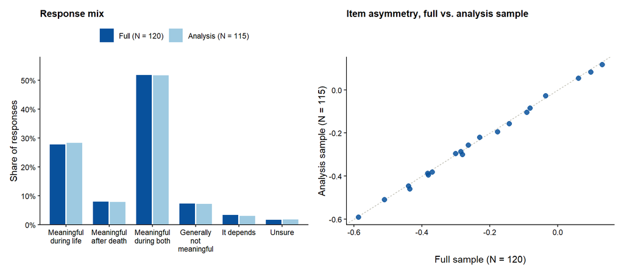

Figure 1. What the exclusions change. Left: the response mix is visually unchanged. Right: each point is one item’s asymmetry before and after exclusion; the dashed line is equality.

Every item moves by at most 0.025 on a scale running from −1 to +1, and the rank ordering is essentially untouched ($\rho$ = 0.992). **The exclusions are defensible on principle, but nothing in Sections 3–4 depends on them.** That is worth stating plainly, because it means the substantive results are not an artifact of a screening choice.

# 2 Sample and Participant Characteristics

The tables in this section describe the **analytic sample** (*N* = 115).

Table 7. Demographic Composition (N = 115)

| Measure | Level | N | % |
| --- | --- | --- | --- |
| Gender | Woman | 58 | 50.4 |
| Gender | Man | 55 | 47.8 |
| Gender | Non-binary | 1 | 0.9 |
| Gender | Prefer not to answer | 1 | 0.9 |
| Age group | 25-34 | 1 | 0.9 |
| Age group | 35-44 | 40 | 34.8 |
| Age group | 45-54 | 37 | 32.2 |
| Age group | 55-64 | 26 | 22.6 |
| Age group | 65-74 | 9 | 7.8 |
| Age group | 75+ | 2 | 1.7 |
| Household income | Less than $25,000 | 9 | 7.8 |
| Household income | $25,000-$49,999 | 22 | 19.1 |
| Household income | $50,000-$74,999 | 27 | 23.5 |
| Household income | $75,000-$99,999 | 11 | 9.6 |
| Household income | $100,000-$150,000 | 22 | 19.1 |
| Household income | $150,000-$200,000 | 11 | 9.6 |
| Household income | $200,000-$250,000 | 7 | 6.1 |
| Household income | $250,000 or more | 1 | 0.9 |
| Household income | Prefer not to answer | 5 | 4.3 |
| Country of birth | United States | 100 | 87.0 |
| Country of birth | Other | 12 | 10.4 |
| Country of birth | Prefer not to say | 3 | 2.6 |

Table 8. Ethnic and Racial Background (Multiple Response)

| Background | N | % of sample |
| --- | --- | --- |
| White / Caucasian | 87 | 75.7 |
| Black American | 14 | 12.2 |
| East Asian | 8 | 7.0 |
| Hispanic / Latino | 5 | 4.3 |
| Black non-American | 3 | 2.6 |
| Southeast Asian | 2 | 1.7 |
| None of the above | 1 | 0.9 |
| Prefer not to answer | 1 | 0.9 |

Select-all-that-apply, so percentages can sum above 100. n = 115.

Table 9. Household and Family Structure

| Measure | Level | N | % |
| --- | --- | --- | --- |
| Has siblings | Yes | 102 | 88.7 |
| Has siblings | No | 13 | 11.3 |
| Has children | Yes | 70 | 60.9 |
| Has children | No | 43 | 37.4 |
| Has children | Prefer not to answer | 2 | 1.7 |
| Has grandchildren | Yes | 21 | 18.3 |
| Has grandchildren | No | 93 | 80.9 |
| Has grandchildren | Prefer not to answer | 1 | 0.9 |

Table 10. Counts Among Those Reporting Any

| Measure | N reporting any | Median | Range |
| --- | --- | --- | --- |
| Siblings | 102 | 2 | 1-9 |
| Children | 70 | 2 | 1-9 |
| Grandchildren | 21 | 2 | 1-8 |

**NoteAge composition differs sharply from the pilot**

99% of this sample is 35 or older and the modal band is 35-44. The classification exercise asks what people want carried forward after death; a sample skewed toward midlife and older adults is closer to the population the estate-planning work targets, and it is a plausible reason for some of the divergence from the pilot in Section 4.

Note also that `age` is stored with **non-sequential Qualtrics recode values**: 18–24 is coded 9, 25–34 is 10, 35–44 is 11, and 45–54 through 75+ are 4–7. Sorting the raw codes numerically produces a scrambled age ordering; the table above uses the survey’s recode map.

# 3 The classification exercise

Twenty items, each classified as meaningful **during life**, **after death**, **during both**, **generally not meaningful to carry forward**, **it depends**, or **unsure**.

Codes 4–6 are a rejection, a conditional, and a non-answer; they are counted separately and never mixed into anything else. 279 of 2,300 responses (12.1%) fell off-scale, a noticeably higher rate than the pilot’s 9.0%.

**Important“Both” is a category, not a midpoint**

*Meaningful during both* is an endorsement of **both** periods at once, not a weak or neutral position between them. Treating it as the middle of a single scale would put an item that everyone agrees matters in both periods in the same place as an item respondents split evenly over — two opposite situations.

So each period gets its **own** endorsement rate, and the two are independent:

| **Life relevance** | share endorsing *during life* — codes **1 or 3** |
| --- | --- |
| **Posthumous relevance** | share endorsing *after death* — codes **2 or 3** |
| **Asymmetry** | posthumous − life relevance. *Both* carries no direction and cancels out, so this is the only directional claim the data supports. |

An item can be high on both measures; that is what a *both*-heavy item looks like, and it is a substantive result rather than a wash.

## 3.1 Dual relevance is the most common answer

Before any ordering, the single largest fact in this table is how often respondents refused the either-or:

Table 11. How the 2,300 Classification Responses Were Distributed Across the Six Options (N = 115)

| Answer | Responses | Share |
| --- | --- | --- |
| Meaningful during life | 652 | 28.3% |
| Meaningful after death | 180 | 7.8% |
| Meaningful during both | 1189 | 51.7% |
| Generally not meaningful | 167 | 7.3% |
| It depends | 71 | 3.1% |
| Unsure | 41 | 1.8% |

**52% of all responses were *both***, more than the two single-period answers combined. The pilot found 43%; at 115 respondents the margin is wider, not narrower. Whatever else the classification task shows, the modal view is that these things are **not** exclusively posthumous: continuation is mostly seen as something already underway during life that carries on, rather than a state that begins at death.

The second thing to notice is how rare *after death* is on its own: 7.8% of responses. **Almost nobody treats any of these twenty items as purely posthumous.**

## 3.2 What each period gets endorsed for

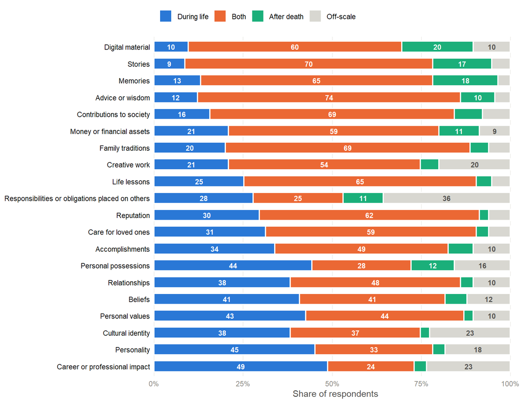

Figure 2. How the retained respondents classified each item, ordered by asymmetry (posthumous minus life relevance). Every bar totals 100%; the pale segment is off-scale (not meaningful, depends, unsure). Percentages are labelled where a segment covers at least 8% of respondents.

The pilot’s headline reading survives: the orange *both* band is present in every row, and it is the largest band in 14 of 20 items. Where the pilot could only say that no item drew zero *both* responses, here every item draws at least 24%.

The ordering separates the same two ends. At the life end sit **career or professional impact, personality, cultural identity, personal values, beliefs, relationships** — things that are *enacted*, that exist in the doing. At the posthumous end sit **digital material, stories, memories, advice or wisdom** — things that can persist as a *record*. That is the enacted/trace distinction the pilot’s open-ended themes arrived at independently, recovered here through a closed-format task on 115 people.

Two differences from the pilot are worth naming now and are taken up in Section 4:

1. **The whole distribution has shifted toward life.** 17 of 20 items are life-leaning here, against 9 of 20 in the pilot.
2. **Off-scale responding is concentrated, not spread.** Responsibilities or obligations placed on others alone drew 36% off-scale answers — the same item the pilot singled out as its outlier.

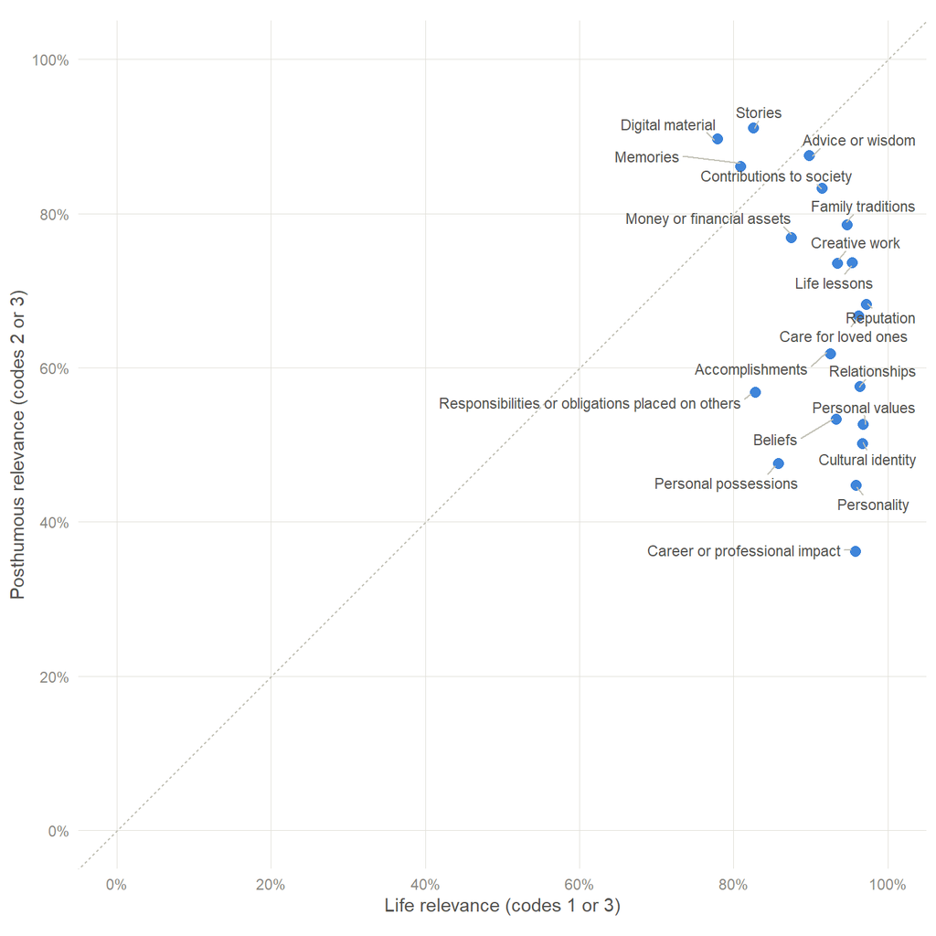

Figure 3. Life relevance against posthumous relevance, both on the full 0-100% scale with a 1:1 aspect ratio so the dashed identity line sits at a true 45 degrees. Points on that line are endorsed equally for both periods; distance up-and-right means an item is widely endorsed for both at once, which is what a ‘both’-heavy item looks like. Points are jittered slightly so ties remain visible.

At 115 respondents nothing reaches unanimity, so the pilot’s “endorsed by **every** respondent” statements have no analogue. What replaces them is sharper: **life relevance is compressed and posthumous relevance is not.** Life relevance spans 78%–97%, a range of 20 points, while posthumous relevance spans 36%–91%, a range 2.8 times wider.

That is the pilot’s central claim, confirmed on a real sample and with a much cleaner signature: **items differ in whether they add a posthumous life, not in whether they matter now.** Everything on this plot is endorsed for life by at least three-quarters of respondents; what separates the items is almost entirely the vertical axis. With both axes on the full scale the identity line makes the point directly: only 3 of 20 items sit above it (memories, stories, digital material), and all three sit barely above — the largest margin is 12 points. Every other item is below the line, most of them far below.

**NoteTwo results worth noticing**

**Money is endorsed more for life than for death** (life 88%, posthumous 77%). The pilot found the same direction on five people; it holds at 115. The single most standard bequest item is *not* read as primarily posthumous. For an estate-planning study this is a substantive finding, not noise.

## 3.3 How many people distinguish the two periods?

Saying *both* is how a respondent declines to separate life from after death for a given item. Counting how often each person does that across the twenty items says how many treat the two periods as genuinely different questions and how many collapse them.

Table 12. How Often Each Participant Chose "Meaningful During Both" (N = 115)

| "Both" answers (of 20) | Participants | % of sample | Mean "during life" only | Mean "after death" only | Mean off-scale |
| --- | --- | --- | --- | --- | --- |
| 0-5 | 15 | 13.0 | 7.9 | 3.1 | 5.5 |
| 6-10 | 46 | 40.0 | 7.2 | 1.9 | 2.7 |
| 11-15 | 40 | 34.8 | 4.6 | 0.8 | 1.6 |
| 16-20 | 14 | 12.2 | 1.4 | 1.0 | 0.6 |

Each participant classified 20 items, so the four bands partition the sample. Median 10 "both" answers, mean 10.3 (SD 4.2), range 0-19. The last three columns describe what each band did with its remaining answers.

**The two extremes are both small, and roughly the same size.** 15 participants (13%) used *both* five times or fewer — these are the people who mostly did commit each item to one period or the other. At the other end, 14 participants (12%) used it sixteen times or more, treating almost nothing as period-specific. The remaining 86 (75%) sit in the middle: they distinguish on some items and not on others.

Two things are worth noting about the shape of this distribution:

- **It is unimodal and centred, not bimodal.** The counts rise to a peak at the middle bands and fall away on both sides (median 10, mean 10.3, SD 4.2). There is no sign of two distinct kinds of respondent — a “separator” type and a “muddler” type. What varies is a threshold, applied by item, and people sit along a continuum of how readily they cross it. 0 participants said *both* to all twenty items and 2 never said it at all.
- **The low-*both* band is not simply making finer distinctions.** Those 15 participants also went off-scale most often — a mean of 5.5 of 20 items, against 0.6 in the high-*both* band. Some of what looks like sharper discrimination is a readiness to answer *not meaningful*, *it depends* or *unsure* instead. Their 3.1 mean *after death only* answers is the highest of any band, though, so the discrimination is real as well.

The practical implication is that 88% of the sample **does** treat the distinction as meaningful for at least some items. The high rate of *both* in Section 3.1 is therefore not a small group of undiscriminating respondents inflating the total — it is most people declining the either-or on most, but not all, items.

### The item ordering is not a by-product of this

Because response style varies this widely, the item ordering in Figure 2 could in principle track who happened to answer which items rather than the items themselves. Subtracting each respondent’s own mean asymmetry before averaging tests that: item asymmetry and style-corrected asymmetry rank-correlate at $\rho$ = 0.998, and 0 respondents used a single code for all twenty items. **The ordering in Figure 2 is a property of the items, not of who answered.**

# 4 Comparison with the open-ended pilot

The pilot (`extended_self_qual.qmd`, *N* = 5) ran the **same twenty items with the same six response options**. This section asks how much of its item-level story survived.

**WarningThree caveats, stated before the numbers**

1. **5 respondents.** A pilot endorsement rate moves by 20 percentage points when one person changes one answer. Nothing below should be read as the pilot being “wrong”; it should be read as the pilot being imprecise, which is what a pilot is.
2. **The pilot had no bot screen.** `extended_self_survey.csv` contains no `fake_*` or `mr_*` items, so the exclusion rules in Section 1 cannot be applied to it. The pilot side of every comparison is unscreened.
3. **Different populations.** The pilot accompanied a long open-ended interview protocol; this sample did the classification exercise on its own and skews older (Section 2).

Table 13. The Same Twenty Items in Both Samples (pilot N = 5, main N = 115)

| Item | Life (pilot) | Life (main) | Post. (pilot) | Post. (main) | Asym. (pilot) | Asym. (main) | Change |
| --- | --- | --- | --- | --- | --- | --- | --- |
| Career or professional impact | 80% | 95% | 40% | 36% | -0.40 | -0.59 | -0.19 |
| Personality | 100% | 96% | 60% | 45% | -0.40 | -0.51 | -0.11 |
| Cultural identity | 50% | 97% | 100% | 51% | +0.50 | -0.46 | -0.96 |
| Personal values | 80% | 97% | 80% | 52% | +0.00 | -0.45 | -0.45 |
| Beliefs | 80% | 93% | 80% | 53% | +0.00 | -0.40 | -0.40 |
| Relationships | 100% | 96% | 40% | 57% | -0.60 | -0.39 | +0.21 |
| Personal possessions | 60% | 86% | 60% | 47% | +0.00 | -0.38 | -0.38 |
| Accomplishments | 75% | 92% | 100% | 62% | +0.25 | -0.30 | -0.55 |
| Care for loved ones | 80% | 96% | 60% | 67% | -0.20 | -0.30 | -0.10 |
| Reputation | 100% | 97% | 75% | 69% | -0.25 | -0.29 | -0.04 |
| Responsibilities or obligations placed on others | 100% | 82% | 33% | 57% | -0.67 | -0.26 | +0.41 |
| Life lessons | 100% | 95% | 40% | 73% | -0.60 | -0.22 | +0.38 |
| Creative work | 60% | 93% | 100% | 74% | +0.40 | -0.20 | -0.60 |
| Family traditions | 75% | 94% | 75% | 79% | +0.00 | -0.16 | -0.16 |
| Money or financial assets | 80% | 88% | 60% | 77% | -0.20 | -0.10 | +0.10 |
| Contributions to society | 75% | 92% | 75% | 83% | +0.00 | -0.08 | -0.08 |
| Advice or wisdom | 100% | 90% | 60% | 87% | -0.40 | -0.03 | +0.37 |
| Memories | 40% | 81% | 100% | 86% | +0.60 | +0.05 | -0.55 |
| Stories | 40% | 83% | 80% | 91% | +0.40 | +0.08 | -0.32 |
| Digital material | 67% | 78% | 100% | 89% | +0.33 | +0.12 | -0.22 |

Ordered by main-sample asymmetry. Pilot percentages rest on at most 5 on-scale responses, so each step there is 20-33 points. Rank correlations, pilot vs. main: asymmetry rho = 0.29 (p = 0.207), posthumous relevance rho = 0.32, life relevance rho = 0.39.

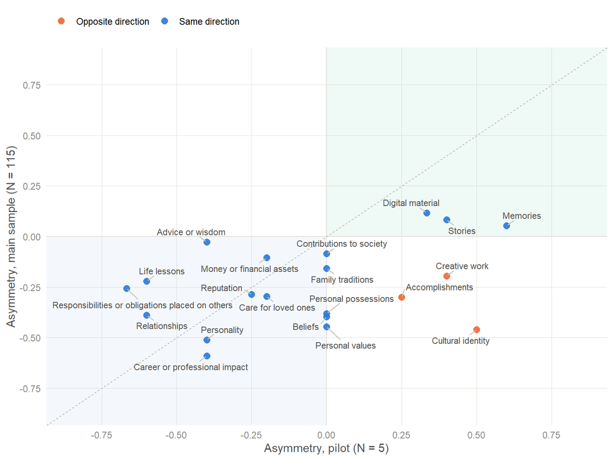

Figure 4. Item asymmetry in the pilot against the main sample. The dashed line is exact agreement; shaded quadrants mark the region where both samples place an item on the same side of zero. Most items sit below the line: the main sample reads the same items as more life-leaning than the pilot did.

15 of 20 items fall **below** the equality line. This is the clearest single result of the comparison, and it is not a ranking effect — it is a level shift. Three-quarters of the items are read as more life-leaning at scale than they were on five people.

- Posthumous end — pilot: memories, cultural identity, creative work. Main: digital material, stories, memories.
- Life end — pilot: responsibilities or obligations placed on others, relationships, life lessons. Main: career or professional impact, personality, cultural identity.

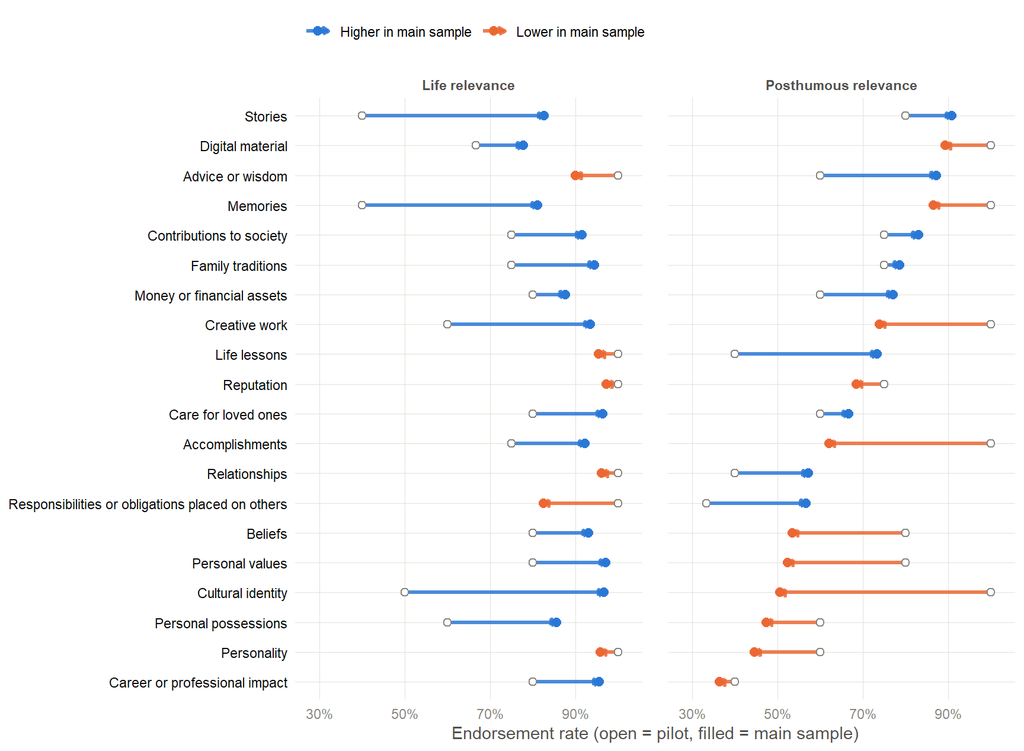

Figure 5. Each item’s endorsement rate in the pilot (open circle) and in the main sample (filled circle), on both measures. Items are ordered by main-sample posthumous relevance. Orange means the main sample is lower than the pilot, blue means higher. Life relevance rises for most items and lands in a narrow band; posthumous relevance moves in both directions and stays spread out.

The two panels behave completely differently. **Life relevance** (left) moves up for 14 of 20 items and lands in a tight band above 78% — the main sample agrees more, and agrees higher, than five people could show. **Posthumous relevance** (right) moves *down* for 11 of 20 items and stays spread out. That is the finding of Section 3.2 seen from the pilot’s vantage point: scale did not shuffle the items so much as pull life relevance up to a ceiling while leaving posthumous relevance free to vary.

A rank correlation of 0.29 reads like a failed replication, but that is not quite the right conclusion. Drawing 5,000 pseudo-pilots of 5 respondents at random from *this* sample and correlating each one’s item ordering against the full-sample values gives a median $\rho$ of only 0.66 (95% range 0.18 to 0.87). **At 5 respondents, perfect replication was never on the table** — the observed 0.29 sits inside the range that sampling error alone produces, at the 6th percentile of that distribution.

The honest reading is therefore in two parts:

- **The pilot’s qualitative conclusions replicate.** *Both* is modal; the enacted/trace distinction orders the extremes; money is life-leaning; responsibilities is the outlier item. None of these depended on precise item positions.
- **The pilot’s item *ordering* does not replicate, and could not have been expected to.** Any statement of the form “item X is more posthumous than item Y” taken from the pilot should be re-derived from this sample rather than carried forward.

# 5 Free-text follow-ups

Three open-ended items accompany the exercise. In the pilot these were `Sort.1`, `Sort.2` and `Sort.2a`; here they are `Q3`, `Q4` and `Q5`.

Table 14. Open-Ended Follow-Ups to the Classification Exercise

| Item | N answered | N substantive | Note |
| --- | --- | --- | --- |
| Q3 - what "it depends" depends on | 89 | 42 | 47 of the 89 answers are placeholders ("n/a", "none", "I didn't select that"). |
| Q4 - anything missing from the exercise | 115 | — | Closed item; see the breakdown below. |
| Q5 - what should have been included | 1 | 1 | Gated on Q4 = Yes. |

Table 15. Q4. Is There Anything Important That Was Missing From the Classification Exercise?

| Level | N | % |
| --- | --- | --- |
| Yes | 1 | 0.9 |
| No | 96 | 83.5 |
| Not sure | 18 | 15.7 |

83% said nothing was missing and only 1 said something was. **The twenty items are treated as a reasonably complete list** — the exercise is not obviously omitting a category respondents feel strongly about.

**A sample of the substantive `Q3` answers**, spanning the length range. These are the conditionals behind the *it depends* code:

> whether it continues to benefit or do possible harm carrying it forward

> reputation is important in both periods because when alive or dead, a person can be respected or hated

> I don’t believe you can physically take anything with you, the only thing would be our faith and where we are headed to after death.

> I selected it for the top choice (responsibilities)- I think it would depend on the type of responsibilites. some could be good (caring for others), and some can be heavy (debt)

> For responsibilities placed on others, it depends on what we’re talking about here. If it’s for care of their health and well being that expires when they pass. If it’s executing a will or trust then that can be a lengthy obligation.

> Digital materials and creative work may have meaning to you, but may or may not have meaning to other people. Even if your family values your work or belongings, they may not want to keep ALL of them after your death, instead only choosing a few momentos to remember you by. The same goes for personal values and financial assets. It’s generally better if you use your financial assets to benefit you and your loved ones while you’re alive so that they have better relationships and memories of you before your death, but if you build up a significant nest egg and can pass it down as inheritance later on, that can also be considered valuable. If you hoard money and do nothing with it for all your life and your loved ones are aware of it, it could HURT your relationships prior to your death. As for personal values, well, they’re personal. I don’t think you should push your values onto other people unless they’re open to it.

The recurring structure is a **sentimental-versus-instrumental** distinction — personal possessions, creative work and digital material are worth carrying forward only when a personal connection attaches to them — and a **burden-versus-gift** distinction for responsibilities. Both are consistent with the pilot’s thematic reading and with which items drew the most off-scale answers here.

# 6 Conclusions

**On the exclusions.** 5 of 120 participants (4.2%) trip a detector, well below the rate in the literacy study. The reverse shibboleth does nearly all the work, and the flagged cases converge on almost identical nutrition estimates, which is a stronger signal than the count alone. Prompt injection caught 1 participant. **Removing the flagged cases changes nothing substantive** — every item’s asymmetry shifts by at most 0.025 — so the results below stand with or without the screen.

**On the classification exercise.**

1. *Both* is the modal answer at 52%, up from the pilot’s 43%. Purely posthumous answers are rare (7.8%).
2. Life relevance is near-universal and compressed (78%–97%); posthumous relevance spreads 2.8 times more widely. **Items differ in whether they add a posthumous life, not in whether they matter now.**
3. The enacted/trace distinction orders the extremes, as in the pilot: records (digital material, stories, memories) lean posthumous; enactments (career impact, personality, values, relationships) lean toward life.
4. Money is life-leaning, and responsibilities placed on others is the item respondents most often refuse to place at all.

**On the pilot.** Its *conclusions* replicate; its *item ordering* does not ($\rho$ = 0.29, against a same-population expectation of 0.66 at *N* = 5). Any ranking claim carried forward from `extended_self_qual.qmd` should be re-derived from this sample.

**Recommendations for the next wave.**

**NoteReproduction notes**

Data: classification_cleaned_data_09.04.26.csv (120 responses, two header rows) and extended_self_survey.csv (5 responses, three header rows). Exclusion rules follow `ep_literacy_analysis.qmd`; classification-exercise definitions follow `extended_self_qual.qmd`. Rendered with R version 4.3.2 (2023-10-31 ucrt).